# Optimal Treatment Analysis

## Outcome Variable

**Outcome Variable:** whz

## Predictor Variables

**Intervention Variable:** mhtcm

**Adjustment Set:**

- arm
- W_mage
- meducyrs
- feducyrs
- single
- delta_W_mage
- delta_meducyrs
- delta_feducyrs
- delta_single

## Stratifying Variables

The analysis was stratified on these variable(s):

- agecat
- studyid
- country

## Data Summary

| agecat | studyid | country | mhtcm | n_cell | n |
| --- | --- | --- | --- | --- | --- |
| Birth | ki0047075b-MAL-ED | BANGLADESH | >=155 cm | 24 | 233 |
| Birth | ki0047075b-MAL-ED | BANGLADESH | <151 cm | 145 | 233 |
| Birth | ki0047075b-MAL-ED | BANGLADESH | [151-155) cm | 64 | 233 |
| Birth | ki0047075b-MAL-ED | BRAZIL | >=155 cm | 105 | 176 |
| Birth | ki0047075b-MAL-ED | BRAZIL | <151 cm | 46 | 176 |
| Birth | ki0047075b-MAL-ED | BRAZIL | [151-155) cm | 25 | 176 |
| Birth | ki0047075b-MAL-ED | INDIA | >=155 cm | 45 | 195 |
| Birth | ki0047075b-MAL-ED | INDIA | <151 cm | 94 | 195 |
| Birth | ki0047075b-MAL-ED | INDIA | [151-155) cm | 56 | 195 |
| Birth | ki0047075b-MAL-ED | NEPAL | >=155 cm | 27 | 167 |
| Birth | ki0047075b-MAL-ED | NEPAL | <151 cm | 93 | 167 |
| Birth | ki0047075b-MAL-ED | NEPAL | [151-155) cm | 47 | 167 |
| Birth | ki0047075b-MAL-ED | PERU | >=155 cm | 56 | 269 |
| Birth | ki0047075b-MAL-ED | PERU | <151 cm | 156 | 269 |
| Birth | ki0047075b-MAL-ED | PERU | [151-155) cm | 57 | 269 |
| Birth | ki0047075b-MAL-ED | SOUTH AFRICA | >=155 cm | 172 | 226 |
| Birth | ki0047075b-MAL-ED | SOUTH AFRICA | <151 cm | 28 | 226 |
| Birth | ki0047075b-MAL-ED | SOUTH AFRICA | [151-155) cm | 26 | 226 |
| Birth | ki0047075b-MAL-ED | TANZANIA, UNITED REPUBLIC OF | >=155 cm | 74 | 116 |
| Birth | ki0047075b-MAL-ED | TANZANIA, UNITED REPUBLIC OF | <151 cm | 19 | 116 |
| Birth | ki0047075b-MAL-ED | TANZANIA, UNITED REPUBLIC OF | [151-155) cm | 23 | 116 |
| Birth | ki1000304b-SAS-CompFeed | INDIA | >=155 cm | 14 | 33 |
| Birth | ki1000304b-SAS-CompFeed | INDIA | <151 cm | 9 | 33 |
| Birth | ki1000304b-SAS-CompFeed | INDIA | [151-155) cm | 10 | 33 |
| Birth | ki1017093-NIH-Birth | BANGLADESH | >=155 cm | 7 | 28 |
| Birth | ki1017093-NIH-Birth | BANGLADESH | <151 cm | 15 | 28 |
| Birth | ki1017093-NIH-Birth | BANGLADESH | [151-155) cm | 6 | 28 |
| Birth | ki1017093c-NIH-Crypto | BANGLADESH | >=155 cm | 4 | 23 |
| Birth | ki1017093c-NIH-Crypto | BANGLADESH | <151 cm | 15 | 23 |
| Birth | ki1017093c-NIH-Crypto | BANGLADESH | [151-155) cm | 4 | 23 |

[output cut: 144 more lines]

The following strata were considered:

- agecat: 24 months, studyid: ki0047075b-MAL-ED, country: BANGLADESH
- agecat: 24 months, studyid: ki0047075b-MAL-ED, country: BRAZIL
- agecat: 24 months, studyid: ki0047075b-MAL-ED, country: INDIA
- agecat: 24 months, studyid: ki0047075b-MAL-ED, country: NEPAL
- agecat: 24 months, studyid: ki0047075b-MAL-ED, country: PERU
- agecat: 24 months, studyid: ki0047075b-MAL-ED, country: SOUTH AFRICA
- agecat: 24 months, studyid: ki0047075b-MAL-ED, country: TANZANIA, UNITED REPUBLIC OF
- agecat: 24 months, studyid: ki1017093-NIH-Birth, country: BANGLADESH
- agecat: 24 months, studyid: ki1017093b-PROVIDE, country: BANGLADESH
- agecat: 24 months, studyid: ki1017093c-NIH-Crypto, country: BANGLADESH
- agecat: 24 months, studyid: ki1066203-TanzaniaChild2, country: TANZANIA, UNITED REPUBLIC OF
- agecat: 24 months, studyid: ki1101329-Keneba, country: GAMBIA
- agecat: 24 months, studyid: ki1119695-PROBIT, country: BELARUS
- agecat: 24 months, studyid: ki1126311-ZVITAMBO, country: ZIMBABWE
- agecat: 24 months, studyid: ki1135781-COHORTS, country: GUATEMALA
- agecat: 24 months, studyid: ki1135781-COHORTS, country: INDIA
- agecat: 24 months, studyid: ki1135781-COHORTS, country: PHILIPPINES
- agecat: 24 months, studyid: ki1148112-LCNI-5, country: MALAWI
- agecat: 24 months, studyid: kiGH5241-JiVitA-3, country: BANGLADESH
- agecat: 6 months, studyid: ki0047075b-MAL-ED, country: BANGLADESH
- agecat: 6 months, studyid: ki0047075b-MAL-ED, country: BRAZIL
- agecat: 6 months, studyid: ki0047075b-MAL-ED, country: INDIA
- agecat: 6 months, studyid: ki0047075b-MAL-ED, country: NEPAL
- agecat: 6 months, studyid: ki0047075b-MAL-ED, country: PERU
- agecat: 6 months, studyid: ki0047075b-MAL-ED, country: SOUTH AFRICA
- agecat: 6 months, studyid: ki0047075b-MAL-ED, country: TANZANIA, UNITED REPUBLIC OF
- agecat: 6 months, studyid: ki1000304b-SAS-CompFeed, country: INDIA
- agecat: 6 months, studyid: ki1000304b-SAS-FoodSuppl, country: INDIA
- agecat: 6 months, studyid: ki1017093-NIH-Birth, country: BANGLADESH
- agecat: 6 months, studyid: ki1017093b-PROVIDE, country: BANGLADESH
- agecat: 6 months, studyid: ki1017093c-NIH-Crypto, country: BANGLADESH
- agecat: 6 months, studyid: ki1066203-TanzaniaChild2, country: TANZANIA, UNITED REPUBLIC OF
- agecat: 6 months, studyid: ki1101329-Keneba, country: GAMBIA
- agecat: 6 months, studyid: ki1112895-Guatemala BSC, country: GUATEMALA
- agecat: 6 months, studyid: ki1119695-PROBIT, country: BELARUS
- agecat: 6 months, studyid: ki1126311-ZVITAMBO, country: ZIMBABWE
- agecat: 6 months, studyid: ki1135781-COHORTS, country: GUATEMALA
- agecat: 6 months, studyid: ki1135781-COHORTS, country: INDIA
- agecat: 6 months, studyid: ki1135781-COHORTS, country: PHILIPPINES
- agecat: 6 months, studyid: ki1148112-LCNI-5, country: MALAWI
- agecat: 6 months, studyid: kiGH5241-JiVitA-3, country: BANGLADESH
- agecat: Birth, studyid: ki0047075b-MAL-ED, country: BANGLADESH
- agecat: Birth, studyid: ki0047075b-MAL-ED, country: BRAZIL
- agecat: Birth, studyid: ki0047075b-MAL-ED, country: INDIA
- agecat: Birth, studyid: ki0047075b-MAL-ED, country: NEPAL
- agecat: Birth, studyid: ki0047075b-MAL-ED, country: PERU
- agecat: Birth, studyid: ki0047075b-MAL-ED, country: SOUTH AFRICA
- agecat: Birth, studyid: ki0047075b-MAL-ED, country: TANZANIA, UNITED REPUBLIC OF
- agecat: Birth, studyid: ki1000304b-SAS-CompFeed, country: INDIA
- agecat: Birth, studyid: ki1017093-NIH-Birth, country: BANGLADESH
- agecat: Birth, studyid: ki1017093c-NIH-Crypto, country: BANGLADESH
- agecat: Birth, studyid: ki1101329-Keneba, country: GAMBIA
- agecat: Birth, studyid: ki1119695-PROBIT, country: BELARUS
- agecat: Birth, studyid: ki1126311-ZVITAMBO, country: ZIMBABWE
- agecat: Birth, studyid: ki1135781-COHORTS, country: GUATEMALA
- agecat: Birth, studyid: ki1135781-COHORTS, country: INDIA
- agecat: Birth, studyid: ki1135781-COHORTS, country: PHILIPPINES
- agecat: Birth, studyid: kiGH5241-JiVitA-3, country: BANGLADESH

### Dropped Strata

Some strata were dropped due to rare outcomes:

- agecat: Birth, studyid: ki1017093c-NIH-Crypto, country: BANGLADESH
- agecat: 24 months, studyid: ki1066203-TanzaniaChild2, country: TANZANIA, UNITED REPUBLIC OF

## Methods Detail

We’re interested in the causal parameters $E[Y_a]$ for all values of $a \in \mathcal{A}$. These parameters represent the mean outcome if, possibly contrary to fact, we intervened to set all units to have $A=a$. Under the randomization and positivity assumptions, these are identified by the statistical parameters $\psi_a=E_W[E_{Y|A,W}(Y|A=a,W)]$. In addition, we’re interested in the mean of $Y$, $E[Y]$ under no intervention (the observed mean). We will estimate these parameters by using SuperLearner to fit the relevant likelihood factors – $E_{Y|A,W}(Y|A=a,W)$ and $p(A=a|W)$, and then updating our likelihood fit using a joint TMLE.

For unadjusted analyses ($W=\{\}$), initial likelihoods were estimated using Lrnr_glm to estimate the simple $E(Y|A)$ and Lrnr_mean to estimate $p(A)$. For adjusted analyses, a small library containing Lrnr_glmnet, Lrnr_xgboost, and Lrnr_mean was used.

Having estimated these parameters, we will then use the delta method to estimate relative risks and attributable risks relative to a prespecified baseline level of $A$.

# Results Detail

## Results Plots

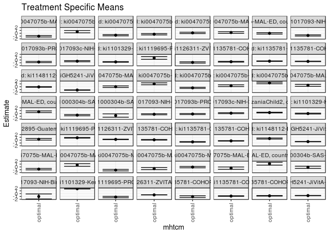

## Results Table

### Parameter: TSM

| agecat | studyid | country | intervention_level | baseline_level | estimate | ci_lower | ci_upper |
| --- | --- | --- | --- | --- | --- | --- | --- |
| Birth | ki0047075b-MAL-ED | BANGLADESH | optimal | observed | -0.7943952 | -1.0498169 | -0.5389734 |
| Birth | ki0047075b-MAL-ED | BRAZIL | optimal | observed | 0.6792995 | 0.2242145 | 1.1343844 |
| Birth | ki0047075b-MAL-ED | INDIA | optimal | observed | -1.1508350 | -1.4227478 | -0.8789221 |
| Birth | ki0047075b-MAL-ED | NEPAL | optimal | observed | -0.6022366 | -0.9657775 | -0.2386957 |
| Birth | ki0047075b-MAL-ED | PERU | optimal | observed | -0.0746759 | -0.3209702 | 0.1716183 |
| Birth | ki0047075b-MAL-ED | SOUTH AFRICA | optimal | observed | -0.4362815 | -0.8408455 | -0.0317174 |
| Birth | ki0047075b-MAL-ED | TANZANIA, UNITED REPUBLIC OF | optimal | observed | 1.1278085 | 0.6209934 | 1.6346236 |
| Birth | ki1000304b-SAS-CompFeed | INDIA | optimal | observed | -0.1376907 | -0.5243980 | 0.2490167 |
| Birth | ki1017093-NIH-Birth | BANGLADESH | optimal | observed | -1.0059989 | -1.8914509 | -0.1205469 |
| Birth | ki1101329-Keneba | GAMBIA | optimal | observed | 1.7435616 | 1.6519263 | 1.8351970 |
| Birth | ki1119695-PROBIT | BELARUS | optimal | observed | -1.2118495 | -1.4459547 | -0.9777442 |
| Birth | ki1126311-ZVITAMBO | ZIMBABWE | optimal | observed | -0.4478310 | -0.4829447 | -0.4127174 |
| Birth | ki1135781-COHORTS | GUATEMALA | optimal | observed | -1.0716822 | -1.3854572 | -0.7579071 |
| Birth | ki1135781-COHORTS | INDIA | optimal | observed | -0.8660873 | -0.9754925 | -0.7566822 |
| Birth | ki1135781-COHORTS | PHILIPPINES | optimal | observed | -0.7749795 | -0.8628623 | -0.6870967 |
| Birth | kiGH5241-JiVitA-3 | BANGLADESH | optimal | observed | -0.6959967 | -0.7503140 | -0.6416795 |
| 6 months | ki0047075b-MAL-ED | BANGLADESH | optimal | observed | 0.0061565 | -0.2742701 | 0.2865830 |
| 6 months | ki0047075b-MAL-ED | BRAZIL | optimal | observed | 1.0286897 | 0.6794949 | 1.3778846 |
| 6 months | ki0047075b-MAL-ED | INDIA | optimal | observed | -0.4048198 | -0.6002814 | -0.2093581 |
| 6 months | ki0047075b-MAL-ED | NEPAL | optimal | observed | 0.3540998 | 0.0502875 | 0.6579121 |
| 6 months | ki0047075b-MAL-ED | PERU | optimal | observed | 1.3491929 | 1.0536254 | 1.6447604 |
| 6 months | ki0047075b-MAL-ED | SOUTH AFRICA | optimal | observed | 0.4838983 | 0.1359819 | 0.8318148 |
| 6 months | ki0047075b-MAL-ED | TANZANIA, UNITED REPUBLIC OF | optimal | observed | 0.6081566 | 0.3135057 | 0.9028075 |
| 6 months | ki1000304b-SAS-CompFeed | INDIA | optimal | observed | -0.6052588 | -0.8336720 | -0.3768456 |
| 6 months | ki1000304b-SAS-FoodSuppl | INDIA | optimal | observed | -0.7427309 | -1.3417172 | -0.1437447 |
| 6 months | ki1017093-NIH-Birth | BANGLADESH | optimal | observed | -0.2978573 | -0.4809718 | -0.1147428 |
| 6 months | ki1017093b-PROVIDE | BANGLADESH | optimal | observed | -0.2010856 | -0.3981961 | -0.0039751 |
| 6 months | ki1017093c-NIH-Crypto | BANGLADESH | optimal | observed | 0.0927824 | -0.0810941 | 0.2666589 |
| 6 months | ki1066203-TanzaniaChild2 | TANZANIA, UNITED REPUBLIC OF | optimal | observed | 0.3100892 | 0.1919695 | 0.4282088 |
| 6 months | ki1101329-Keneba | GAMBIA | optimal | observed | -0.0388765 | -0.1863828 | 0.1086298 |
| 6 months | ki1112895-Guatemala BSC | GUATEMALA | optimal | observed | 0.3125528 | 0.0159133 | 0.6091923 |
| 6 months | ki1119695-PROBIT | BELARUS | optimal | observed | 0.8493836 | 0.7183144 | 0.9804528 |
| 6 months | ki1126311-ZVITAMBO | ZIMBABWE | optimal | observed | 0.2738189 | 0.1878610 | 0.3597767 |
| 6 months | ki1135781-COHORTS | GUATEMALA | optimal | observed | 0.1335668 | 0.0011154 | 0.2660182 |
| 6 months | ki1135781-COHORTS | INDIA | optimal | observed | -0.6105419 | -0.7120400 | -0.5090438 |
| 6 months | ki1135781-COHORTS | PHILIPPINES | optimal | observed | -0.2506455 | -0.3319340 | -0.1693570 |
| 6 months | ki1148112-LCNI-5 | MALAWI | optimal | observed | 0.5768710 | 0.3862308 | 0.7675112 |
| 6 months | kiGH5241-JiVitA-3 | BANGLADESH | optimal | observed | -0.5106867 | -0.5733383 | -0.4480350 |
| 24 months | ki0047075b-MAL-ED | BANGLADESH | optimal | observed | -1.0619960 | -1.3222643 | -0.8017276 |
| 24 months | ki0047075b-MAL-ED | BRAZIL | optimal | observed | 0.5597248 | 0.1610791 | 0.9583704 |
| 24 months | ki0047075b-MAL-ED | INDIA | optimal | observed | -0.6946344 | -0.9259026 | -0.4633661 |
| 24 months | ki0047075b-MAL-ED | NEPAL | optimal | observed | -0.3449427 | -0.5892070 | -0.1006784 |
| 24 months | ki0047075b-MAL-ED | PERU | optimal | observed | 0.1441747 | -0.1040331 | 0.3923825 |
| 24 months | ki0047075b-MAL-ED | SOUTH AFRICA | optimal | observed | 0.2613434 | -0.0378218 | 0.5605086 |
| 24 months | ki0047075b-MAL-ED | TANZANIA, UNITED REPUBLIC OF | optimal | observed | -0.0324406 | -0.2859149 | 0.2210336 |
| 24 months | ki1017093-NIH-Birth | BANGLADESH | optimal | observed | -0.7836938 | -0.9882511 | -0.5791366 |
| 24 months | ki1017093b-PROVIDE | BANGLADESH | optimal | observed | -0.7211707 | -0.9359687 | -0.5063727 |
| 24 months | ki1017093c-NIH-Crypto | BANGLADESH | optimal | observed | -0.4262369 | -0.6309686 | -0.2215051 |
| 24 months | ki1101329-Keneba | GAMBIA | optimal | observed | -0.6776661 | -0.8198802 | -0.5354520 |
| 24 months | ki1119695-PROBIT | BELARUS | optimal | observed | 0.7205502 | 0.2374295 | 1.2036710 |
| 24 months | ki1126311-ZVITAMBO | ZIMBABWE | optimal | observed | -0.8681063 | -1.0901202 | -0.6460924 |
| 24 months | ki1135781-COHORTS | GUATEMALA | optimal | observed | -0.6137418 | -0.7449672 | -0.4825165 |
| 24 months | ki1135781-COHORTS | INDIA | optimal | observed | -0.4149349 | -0.5029821 | -0.3268876 |
| 24 months | ki1135781-COHORTS | PHILIPPINES | optimal | observed | -0.4977497 | -0.5768435 | -0.4186559 |
| 24 months | ki1148112-LCNI-5 | MALAWI | optimal | observed | -0.0768456 | -0.2148843 | 0.0611931 |
| 24 months | kiGH5241-JiVitA-3 | BANGLADESH | optimal | observed | -1.1780965 | -1.2529367 | -1.1032562 |

### Parameter: E(Y)

| agecat | studyid | country | intervention_level | baseline_level | estimate | ci_lower | ci_upper |
| --- | --- | --- | --- | --- | --- | --- | --- |
| Birth | ki0047075b-MAL-ED | BANGLADESH | observed | observed | -0.9724464 | -1.1091046 | -0.8357881 |
| Birth | ki0047075b-MAL-ED | BRAZIL | observed | observed | 0.3832386 | 0.2044597 | 0.5620175 |
| Birth | ki0047075b-MAL-ED | INDIA | observed | observed | -1.0698974 | -1.2115847 | -0.9282102 |
| Birth | ki0047075b-MAL-ED | NEPAL | observed | observed | -0.9126946 | -1.0520834 | -0.7733058 |
| Birth | ki0047075b-MAL-ED | PERU | observed | observed | -0.0660967 | -0.1789362 | 0.0467429 |
| Birth | ki0047075b-MAL-ED | SOUTH AFRICA | observed | observed | -0.0346018 | -0.1831486 | 0.1139451 |
| Birth | ki0047075b-MAL-ED | TANZANIA, UNITED REPUBLIC OF | observed | observed | 0.7950000 | 0.5947353 | 0.9952647 |
| Birth | ki1000304b-SAS-CompFeed | INDIA | observed | observed | -0.1627273 | -0.3719320 | 0.0464775 |
| Birth | ki1017093-NIH-Birth | BANGLADESH | observed | observed | -1.4239286 | -1.7688028 | -1.0790544 |
| Birth | ki1101329-Keneba | GAMBIA | observed | observed | 1.7101663 | 1.6251406 | 1.7951919 |
| Birth | ki1119695-PROBIT | BELARUS | observed | observed | -1.1836519 | -1.5174268 | -0.8498771 |
| Birth | ki1126311-ZVITAMBO | ZIMBABWE | observed | observed | -0.4901203 | -0.5209592 | -0.4592815 |
| Birth | ki1135781-COHORTS | GUATEMALA | observed | observed | -1.2657337 | -1.4050782 | -1.1263892 |
| Birth | ki1135781-COHORTS | INDIA | observed | observed | -0.9773926 | -1.0345102 | -0.9202750 |
| Birth | ki1135781-COHORTS | PHILIPPINES | observed | observed | -0.7427251 | -0.7890855 | -0.6963647 |
| Birth | kiGH5241-JiVitA-3 | BANGLADESH | observed | observed | -0.7661866 | -0.7931615 | -0.7392117 |
| 6 months | ki0047075b-MAL-ED | BANGLADESH | observed | observed | -0.1397960 | -0.2688682 | -0.0107238 |
| 6 months | ki0047075b-MAL-ED | BRAZIL | observed | observed | 0.9717225 | 0.8073791 | 1.1360658 |
| 6 months | ki0047075b-MAL-ED | INDIA | observed | observed | -0.6987943 | -0.8241325 | -0.5734561 |
| 6 months | ki0047075b-MAL-ED | NEPAL | observed | observed | 0.1110452 | -0.0202712 | 0.2423616 |
| 6 months | ki0047075b-MAL-ED | PERU | observed | observed | 1.0563787 | 0.9342938 | 1.1784635 |
| 6 months | ki0047075b-MAL-ED | SOUTH AFRICA | observed | observed | 0.5290428 | 0.3750394 | 0.6830463 |
| 6 months | ki0047075b-MAL-ED | TANZANIA, UNITED REPUBLIC OF | observed | observed | 0.5170513 | 0.3872178 | 0.6468847 |
| 6 months | ki1000304b-SAS-CompFeed | INDIA | observed | observed | -0.7684530 | -0.9589959 | -0.5779101 |
| 6 months | ki1000304b-SAS-FoodSuppl | INDIA | observed | observed | -1.1045833 | -1.3327472 | -0.8764195 |
| 6 months | ki1017093-NIH-Birth | BANGLADESH | observed | observed | -0.4389101 | -0.5279432 | -0.3498771 |
| 6 months | ki1017093b-PROVIDE | BANGLADESH | observed | observed | -0.2079891 | -0.2925599 | -0.1234183 |
| 6 months | ki1017093c-NIH-Crypto | BANGLADESH | observed | observed | 0.0297622 | -0.0491685 | 0.1086930 |
| 6 months | ki1066203-TanzaniaChild2 | TANZANIA, UNITED REPUBLIC OF | observed | observed | 0.0787757 | 0.0256721 | 0.1318793 |
| 6 months | ki1101329-Keneba | GAMBIA | observed | observed | -0.2054148 | -0.2588995 | -0.1519302 |
| 6 months | ki1112895-Guatemala BSC | GUATEMALA | observed | observed | -0.0255916 | -0.1507513 | 0.0995680 |
| 6 months | ki1119695-PROBIT | BELARUS | observed | observed | 0.5803622 | 0.5051894 | 0.6555350 |
| 6 months | ki1126311-ZVITAMBO | ZIMBABWE | observed | observed | 0.2928354 | 0.2648888 | 0.3207820 |
| 6 months | ki1135781-COHORTS | GUATEMALA | observed | observed | 0.0531648 | -0.0564716 | 0.1628012 |
| 6 months | ki1135781-COHORTS | INDIA | observed | observed | -0.6768114 | -0.7301317 | -0.6234912 |
| 6 months | ki1135781-COHORTS | PHILIPPINES | observed | observed | -0.2938433 | -0.3352064 | -0.2524802 |
| 6 months | ki1148112-LCNI-5 | MALAWI | observed | observed | 0.4515431 | 0.3802415 | 0.5228446 |
| 6 months | kiGH5241-JiVitA-3 | BANGLADESH | observed | observed | -0.5889448 | -0.6164744 | -0.5614153 |
| 24 months | ki0047075b-MAL-ED | BANGLADESH | observed | observed | -0.8208255 | -0.9429246 | -0.6987264 |
| 24 months | ki0047075b-MAL-ED | BRAZIL | observed | observed | 0.4466272 | 0.2416144 | 0.6516401 |
| 24 months | ki0047075b-MAL-ED | INDIA | observed | observed | -0.9525664 | -1.0684455 | -0.8366872 |
| 24 months | ki0047075b-MAL-ED | NEPAL | observed | observed | -0.3764474 | -0.4898516 | -0.2630431 |
| 24 months | ki0047075b-MAL-ED | PERU | observed | observed | 0.1199005 | -0.0000331 | 0.2398341 |
| 24 months | ki0047075b-MAL-ED | SOUTH AFRICA | observed | observed | 0.4096154 | 0.2902946 | 0.5289362 |
| 24 months | ki0047075b-MAL-ED | TANZANIA, UNITED REPUBLIC OF | observed | observed | 0.0500935 | -0.0748234 | 0.1750103 |
| 24 months | ki1017093-NIH-Birth | BANGLADESH | observed | observed | -0.9115790 | -1.0095022 | -0.8136559 |
| 24 months | ki1017093b-PROVIDE | BANGLADESH | observed | observed | -0.8864991 | -0.9695215 | -0.8034768 |
| 24 months | ki1017093c-NIH-Crypto | BANGLADESH | observed | observed | -0.6103502 | -0.7050157 | -0.5156847 |
| 24 months | ki1101329-Keneba | GAMBIA | observed | observed | -0.8101717 | -0.8592463 | -0.7610970 |
| 24 months | ki1119695-PROBIT | BELARUS | observed | observed | 0.8069040 | 0.6553606 | 0.9584474 |
| 24 months | ki1126311-ZVITAMBO | ZIMBABWE | observed | observed | -1.1803611 | -1.2905182 | -1.0702040 |
| 24 months | ki1135781-COHORTS | GUATEMALA | observed | observed | -0.5761618 | -0.6548073 | -0.4975163 |
| 24 months | ki1135781-COHORTS | INDIA | observed | observed | -0.5719523 | -0.6185009 | -0.5254037 |
| 24 months | ki1135781-COHORTS | PHILIPPINES | observed | observed | -0.6099592 | -0.6467541 | -0.5731643 |
| 24 months | ki1148112-LCNI-5 | MALAWI | observed | observed | -0.0469519 | -0.1290932 | 0.0351895 |
| 24 months | kiGH5241-JiVitA-3 | BANGLADESH | observed | observed | -1.2923557 | -1.3250399 | -1.2596715 |

### Parameter: PAR

| agecat | studyid | country | intervention_level | baseline_level | estimate | ci_lower | ci_upper |
| --- | --- | --- | --- | --- | --- | --- | --- |
| Birth | ki0047075b-MAL-ED | BANGLADESH | optimal | observed | -0.1780512 | -0.4209305 | 0.0648281 |
| Birth | ki0047075b-MAL-ED | BRAZIL | optimal | observed | -0.2960608 | -0.7045553 | 0.1124336 |
| Birth | ki0047075b-MAL-ED | INDIA | optimal | observed | 0.0809375 | -0.1490210 | 0.3108960 |
| Birth | ki0047075b-MAL-ED | NEPAL | optimal | observed | -0.3104580 | -0.6418079 | 0.0208919 |
| Birth | ki0047075b-MAL-ED | PERU | optimal | observed | 0.0085793 | -0.2010551 | 0.2182137 |
| Birth | ki0047075b-MAL-ED | SOUTH AFRICA | optimal | observed | 0.4016797 | 0.0267005 | 0.7766589 |
| Birth | ki0047075b-MAL-ED | TANZANIA, UNITED REPUBLIC OF | optimal | observed | -0.3328085 | -0.7993133 | 0.1336963 |
| Birth | ki1000304b-SAS-CompFeed | INDIA | optimal | observed | -0.0250366 | -0.4054516 | 0.3553784 |
| Birth | ki1017093-NIH-Birth | BANGLADESH | optimal | observed | -0.4179297 | -1.2133269 | 0.3774676 |
| Birth | ki1101329-Keneba | GAMBIA | optimal | observed | -0.0333953 | -0.0748235 | 0.0080328 |
| Birth | ki1119695-PROBIT | BELARUS | optimal | observed | 0.0281975 | -0.1070389 | 0.1634340 |
| Birth | ki1126311-ZVITAMBO | ZIMBABWE | optimal | observed | -0.0422893 | -0.0599179 | -0.0246606 |
| Birth | ki1135781-COHORTS | GUATEMALA | optimal | observed | -0.1940515 | -0.4734471 | 0.0853440 |
| Birth | ki1135781-COHORTS | INDIA | optimal | observed | -0.1113053 | -0.2045634 | -0.0180472 |
| Birth | ki1135781-COHORTS | PHILIPPINES | optimal | observed | 0.0322544 | -0.0418337 | 0.1063426 |
| Birth | kiGH5241-JiVitA-3 | BANGLADESH | optimal | observed | -0.0701899 | -0.1178043 | -0.0225754 |
| 6 months | ki0047075b-MAL-ED | BANGLADESH | optimal | observed | -0.1459525 | -0.4058890 | 0.1139841 |
| 6 months | ki0047075b-MAL-ED | BRAZIL | optimal | observed | -0.0569673 | -0.3580852 | 0.2441507 |
| 6 months | ki0047075b-MAL-ED | INDIA | optimal | observed | -0.2939746 | -0.4684921 | -0.1194570 |
| 6 months | ki0047075b-MAL-ED | NEPAL | optimal | observed | -0.2430546 | -0.5233613 | 0.0372522 |
| 6 months | ki0047075b-MAL-ED | PERU | optimal | observed | -0.2928142 | -0.5531165 | -0.0325119 |
| 6 months | ki0047075b-MAL-ED | SOUTH AFRICA | optimal | observed | 0.0451445 | -0.2945095 | 0.3847985 |
| 6 months | ki0047075b-MAL-ED | TANZANIA, UNITED REPUBLIC OF | optimal | observed | -0.0911053 | -0.3572843 | 0.1750737 |
| 6 months | ki1000304b-SAS-CompFeed | INDIA | optimal | observed | -0.1631943 | -0.2723568 | -0.0540317 |
| 6 months | ki1000304b-SAS-FoodSuppl | INDIA | optimal | observed | -0.3618524 | -0.9068892 | 0.1831844 |
| 6 months | ki1017093-NIH-Birth | BANGLADESH | optimal | observed | -0.1410528 | -0.2979075 | 0.0158018 |
| 6 months | ki1017093b-PROVIDE | BANGLADESH | optimal | observed | -0.0069035 | -0.1782552 | 0.1644482 |
| 6 months | ki1017093c-NIH-Crypto | BANGLADESH | optimal | observed | -0.0630201 | -0.2158721 | 0.0898319 |
| 6 months | ki1066203-TanzaniaChild2 | TANZANIA, UNITED REPUBLIC OF | optimal | observed | -0.2313135 | -0.3396705 | -0.1229565 |
| 6 months | ki1101329-Keneba | GAMBIA | optimal | observed | -0.1665383 | -0.3048500 | -0.0282267 |
| 6 months | ki1112895-Guatemala BSC | GUATEMALA | optimal | observed | -0.3381444 | -0.6161363 | -0.0601525 |
| 6 months | ki1119695-PROBIT | BELARUS | optimal | observed | -0.2690215 | -0.3935950 | -0.1444479 |
| 6 months | ki1126311-ZVITAMBO | ZIMBABWE | optimal | observed | 0.0190165 | -0.0614034 | 0.0994365 |
| 6 months | ki1135781-COHORTS | GUATEMALA | optimal | observed | -0.0804020 | -0.1562427 | -0.0045612 |
| 6 months | ki1135781-COHORTS | INDIA | optimal | observed | -0.0662695 | -0.1507180 | 0.0181789 |
| 6 months | ki1135781-COHORTS | PHILIPPINES | optimal | observed | -0.0431978 | -0.1126693 | 0.0262737 |
| 6 months | ki1148112-LCNI-5 | MALAWI | optimal | observed | -0.1253279 | -0.3002823 | 0.0496264 |
| 6 months | kiGH5241-JiVitA-3 | BANGLADESH | optimal | observed | -0.0782581 | -0.1347577 | -0.0217586 |
| 24 months | ki0047075b-MAL-ED | BANGLADESH | optimal | observed | 0.2411705 | -0.0050784 | 0.4874194 |
| 24 months | ki0047075b-MAL-ED | BRAZIL | optimal | observed | -0.1130975 | -0.4306515 | 0.2044564 |
| 24 months | ki0047075b-MAL-ED | INDIA | optimal | observed | -0.2579320 | -0.4679014 | -0.0479626 |
| 24 months | ki0047075b-MAL-ED | NEPAL | optimal | observed | -0.0315047 | -0.2629328 | 0.1999235 |
| 24 months | ki0047075b-MAL-ED | PERU | optimal | observed | -0.0242742 | -0.2492322 | 0.2006838 |
| 24 months | ki0047075b-MAL-ED | SOUTH AFRICA | optimal | observed | 0.1482720 | -0.1063915 | 0.4029355 |
| 24 months | ki0047075b-MAL-ED | TANZANIA, UNITED REPUBLIC OF | optimal | observed | 0.0825341 | -0.1317976 | 0.2968658 |
| 24 months | ki1017093-NIH-Birth | BANGLADESH | optimal | observed | -0.1278852 | -0.3090951 | 0.0533247 |
| 24 months | ki1017093b-PROVIDE | BANGLADESH | optimal | observed | -0.1653285 | -0.3500029 | 0.0193460 |
| 24 months | ki1017093c-NIH-Crypto | BANGLADESH | optimal | observed | -0.1841133 | -0.3691350 | 0.0009083 |
| 24 months | ki1101329-Keneba | GAMBIA | optimal | observed | -0.1325056 | -0.2650717 | 0.0000606 |
| 24 months | ki1119695-PROBIT | BELARUS | optimal | observed | 0.0863538 | -0.3751282 | 0.5478358 |
| 24 months | ki1126311-ZVITAMBO | ZIMBABWE | optimal | observed | -0.3122548 | -0.5205303 | -0.1039794 |
| 24 months | ki1135781-COHORTS | GUATEMALA | optimal | observed | 0.0375800 | -0.0609109 | 0.1360710 |
| 24 months | ki1135781-COHORTS | INDIA | optimal | observed | -0.1570174 | -0.2300344 | -0.0840004 |
| 24 months | ki1135781-COHORTS | PHILIPPINES | optimal | observed | -0.1122095 | -0.1827408 | -0.0416781 |
| 24 months | ki1148112-LCNI-5 | MALAWI | optimal | observed | 0.0298937 | -0.0759865 | 0.1357740 |
| 24 months | kiGH5241-JiVitA-3 | BANGLADESH | optimal | observed | -0.1142592 | -0.1853782 | -0.0431403 |